# xwMOOC 기계학습

단변량/다변량 이상점 검출 - 사기 탐지

xwMOOC

Tidyverse Korea

2018-11-15

# 1 이상점 탐지 방법론 [^1]

이상점 탐지 기법을 통해 사기탐지(fraud detection)에도 응용이 가능하다. [Outlier Detection Techniques](http://www.dbs.ifi.lmu.de/~zimek/publications/KDD2010/kdd10-outlier-tutorial.pdf) 발표자료에 의하면 정말 다양한 이상점 탐지 방법이 제시되고 있다.

- 모형기반 (Model-based)
  - 통계검증 (Statistical Tests)
  - 깊이 기반 접근법(Depth-based Approaches)
  - 편차 기반 접근법(Deviation-based Approaches)
- 근접기반 (Proximity-based)
  - 거리 기반(Distance-based Approaches)
  - 밀도 기반(Density-based Approaches)
- 고차원 접근법 (High dimensional Approaches)

# 2 소득 천분위 자료 사례 [^2]

심상정 국회의원은 국세청으로부터 제출받은 지난해 소득 천분위 자료를 최초로 분석했습니다. 근로소득뿐만 아니라 이자·배당·종합소득 천분위 자료까지 국세청으로부터 확보하여 소득주도성장을 둘러싼 논란이 한창인 이 시점 소득의 실상을 정확히 아는 것이 무엇보다 중요하다는 점을 분명히 했습니다.

이 분석 자료를 보면 소득양극화의 결과가 상위 1%, 나아가 0.1%의 소득에 의해 주도된다는 점을 확인하면서 국세청 데이터를 근거로 다음을 들고 있습니다.

- 근로소득 상위 0.1%의 1인당 평균은 6억 5천만원으로 하위 10%의 69만원보다 1천배 가까이 많음.
- 상위 0.1%의 #이자소득 총액은 2조 5078억으로 전체의 17.79%를 차지했고, #배당소득 은 7조 2896억으로 전체의 51.75%에 달함. - 이자·배당·부동산임대·사업·근로·기타소득을 모두 합산한 종합소득을 살펴보면, 상위 0.1%가 1인당 25억 8900만원을 벌었는데 반해, 하위 10%는 1인당 평균 193만원으로 월 17만원에 못미침.

따라서, 소득 양극화가 극심한 것이 국세청 자료를 통해 확인된만큼 소득격차를 해소를 위한 최저임금 인상, 임금공시제, 노동이사제, 최고임금제 (살찐 고양이법) 뿐만 아니라, 슈퍼리치들의 돈잔치가 되고 있는 이자소득과 배당소득 등 불로소득에 대한 금융과세, 보유세 등 적극적인 불평등 해소 대책을 강력하게 병행을 주장.

## 2.1 데이터

[심상정, 소득 천분위 자료 공개 (종합, 근로, 배당, 이자 소득) 블로그](https://blog.naver.com/713sim/221350785950)에서 데이터를 엑셀형태로 다운로드 받을 수 있습니다. 이를 데이터 분석이 가능한 형태로 정제작업을 수행합니다. 인원은 명수, 기타 금액은 단위가 억원입니다.

```r
# 팩키지 ----
library(readxl)
library(tidyverse)

# 데이터 가져오기 ----
inc_2016_dat <- read_excel("data/근로소득천분위.xlsx", sheet="2016", skip=3) %>%
  mutate(`연도` = 2016)
inc_2015_dat <- read_excel("data/근로소득천분위.xlsx", sheet="2015", skip=3) %>%
  mutate(`연도` = 2015)
inc_2014_dat <- read_excel("data/근로소득천분위.xlsx", sheet="2014", skip=3) %>%
  mutate(`연도` = 2014)
inc_2013_dat <- read_excel("data/근로소득천분위.xlsx", sheet="2013", skip=3) %>%
  mutate(`연도` = 2013)

# 데이터와 사투시작 ----
inc_dat <- bind_rows(inc_2013_dat, inc_2014_dat) %>%
  bind_rows(inc_2015_dat) %>%
  bind_rows(inc_2016_dat)

inc_df <- inc_dat %>%
  filter(!str_detect(`구분`, "합계")) %>%
  mutate(`연도` = factor(`연도`)) %>%
  mutate(`천분위수` = 1000 - parse_number(`구분`) %>% ntile(1000)) %>%
  mutate(`인당급여` = `총급여`/`인원`,
         `인당근로소득` = `근로소득금액`/`인원`,
         `인당비근로소득` = (`총급여` - `근로소득금액`)/`인원`)

inc_df %>%
  DT::datatable() %>%
    DT::formatRound(c(2:7), digits=0) %>%
    DT::formatRound(c(10:12), digits=2)
```

|  | 구분 | 인원 | 총급여 | 근로소득금액 | 소득공제액 합계 | 과세표준 | 결정세액 | 연도 | 천분위수 | 인당급여 | 인당근로소득 | 인당비근로소득 |
| --- | --- | --- | --- | --- | --- | --- | --- | --- | --- | --- | --- | --- |
| 1 | 상위 0.1% 내 | 16360 | 104268 | 98058 | 12477 | 91790 | 28986 | 2013 | 999 | 6.37334963325183 | 5.99376528117359 | 0.37958435207824 |
| 2 | 상위 0.2% 내 | 16360 | 45548 | 41889 | 8048 | 37500 | 10026 | 2013 | 998 | 2.7841075794621 | 2.56045232273839 | 0.223655256723716 |
| 3 | 상위 0.3% 내 | 16360 | 36180 | 32892 | 7476 | 28704 | 7169 | 2013 | 997 | 2.21149144254279 | 2.01051344743276 | 0.200977995110024 |
| 4 | 상위 0.4% 내 | 16360 | 31222 | 28086 | 7340 | 23882 | 5637 | 2013 | 996 | 1.90843520782396 | 1.71674816625917 | 0.191687041564792 |
| 5 | 상위 0.5% 내 | 16359 | 28267 | 25236 | 7252 | 21016 | 4691 | 2013 | 995 | 1.72791735436151 | 1.54263708050614 | 0.18528027385537 |
| 6 | 상위 0.6% 내 | 16360 | 26150 | 23191 | 7223 | 18927 | 4009 | 2013 | 994 | 1.59841075794621 | 1.41754278728606 | 0.180867970660147 |
| 7 | 상위 0.7% 내 | 16360 | 24642 | 21739 | 7198 | 17444 | 3525 | 2013 | 993 | 1.50623471882641 | 1.32878973105134 | 0.177444987775061 |
| 8 | 상위 0.8% 내 | 16360 | 23517 | 20653 | 7195 | 16322 | 3158 | 2013 | 992 | 1.43746943765281 | 1.26240831295844 | 0.175061124694377 |
| 9 | 상위 0.9% 내 | 16359 | 22622 | 19792 | 7223 | 15400 | 2866 | 2013 | 991 | 1.38284736230821 | 1.20985390305031 | 0.172993459257901 |
| 10 | 상위 1.0% 내 | 16360 | 21886 | 19086 | 7199 | 14687 | 2648 | 2013 | 990 | 1.33777506112469 | 1.16662591687042 | 0.171149144254279 |

[output cut: 3990 more lines]

## 2.2 탐색적 데이터분석 [^3]

### 2.2.1 연도별 천분위 소득 변화

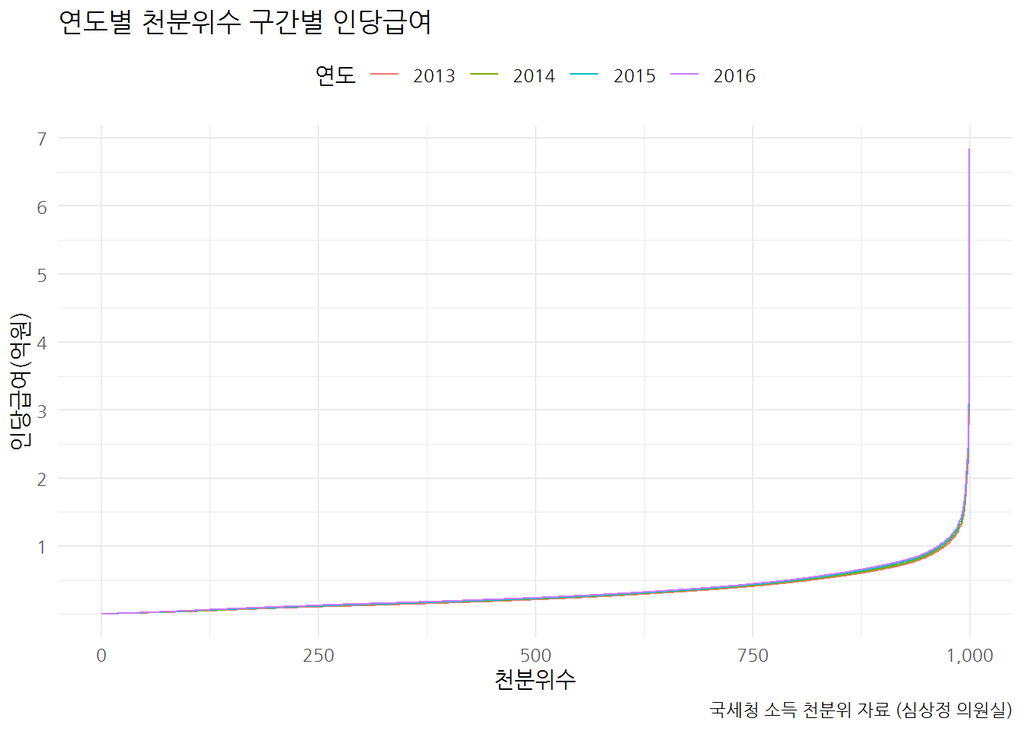

```r
library(extrafont)
loadfonts()

inc_df %>%
  ggplot(aes(x=`천분위수`, y=`인당급여`, color=`연도`)) +
    # geom_point() +
    geom_line() +
    scale_y_continuous(breaks = c(1:7)) +
    scale_x_continuous(labels = scales::comma) +
    theme_minimal(base_family = "NanumGothic") +
    labs(x="천분위수", y="인당급여(억원)",
         title="연도별 천분위수 구간별 인당급여",
         caption = "국세청 소득 천분위 자료 (심상정 의원실)") +
    theme(legend.position = "top")
```

### 2.2.2 연도별 천분위 소득 분포

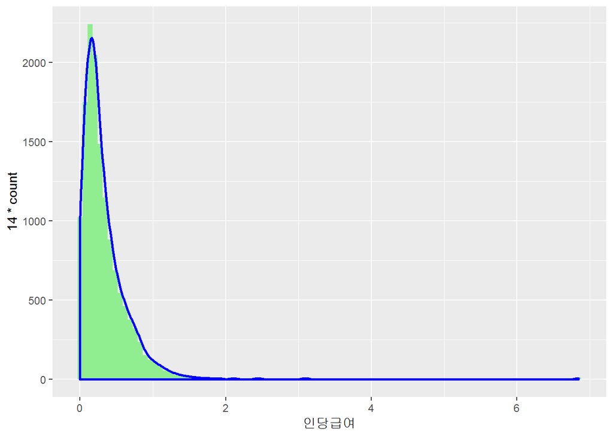

```r
library(fitdistrplus)

## 원데이터 소득 분포
inc_v <- inc_df %>%
  filter(`연도` == 2016) %>%
  pull(`인당급여`)

inc_df %>%
  filter(`연도` == 2016) %>%
  ggplot(aes(x=`인당급여`)) +
    geom_histogram(aes(y=14*..count..), bins=100, fill="lightgreen") +
    geom_density(aes(y=..count..), color="blue", size=1) +
    scale_x_continuous()
```

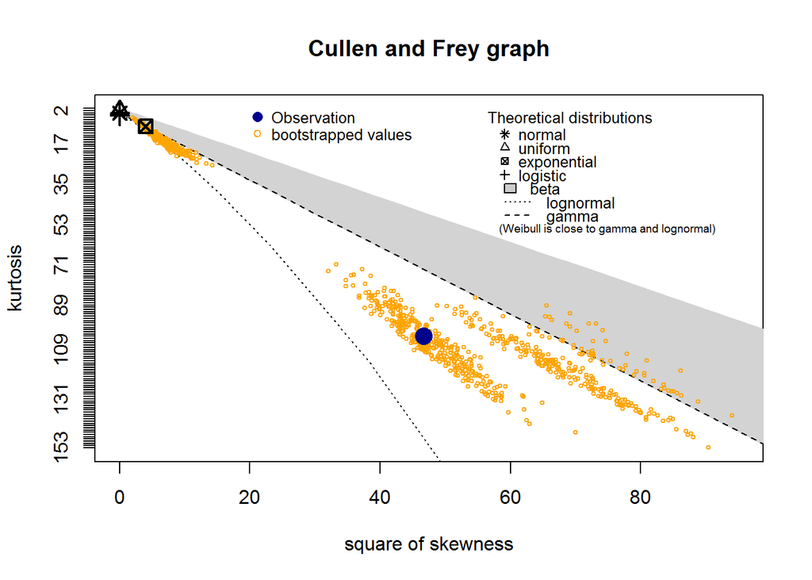

```
summary statistics
------
min:  0   max:  6.845152
median:  0.2400225
mean:  0.335957
estimated sd:  0.370417
estimated skewness:  6.830315
estimated kurtosis:  102.8481
```

```r
descdist(inc_v, boot = 1000)
```

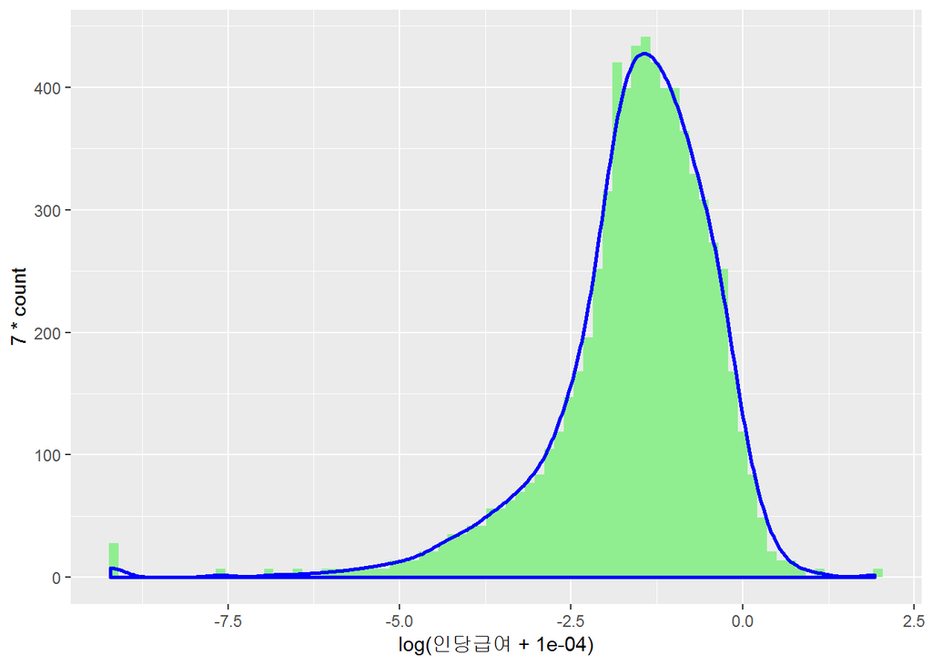

```r
## 로그변환 (정규) 급여분포

inc_df %>%
  filter(`연도` == 2016) %>%
  ggplot(aes(x=log(`인당급여` + 0.0001))) +
    geom_histogram(aes(y=7*..count..), bins=80, fill="lightgreen") +
    geom_density(aes(y=..count..), color="blue", size=1) +
    scale_x_continuous()
```

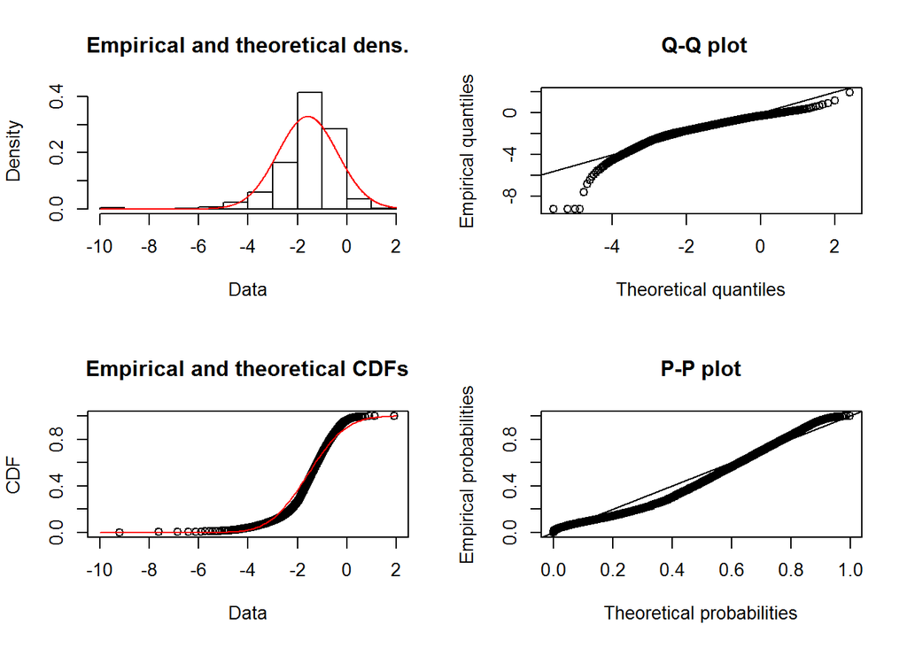

```r
inc_2016_dist <- fitdist(log(inc_v + 0.0001), "norm")

plotdist(log(inc_v + 0.0001), "norm",
         para=list(mean = inc_2016_dist$estimate[1],
                   sd   = inc_2016_dist$estimate[2]))
```

### 2.2.3 지니계수 [^4]

```r
library(ineq)

inc_lc <- inc_df %>%
  dplyr::select(`연도`, `인당급여`) %>%
  group_by(`연도`) %>%
  nest()

inc_lc %>%
  mutate(`지니계수` = map_dbl(data, ~ineq(.x$`인당급여`))) %>%
  dplyr::select(`연도`, `지니계수`) %>%
  DT::datatable() %>%
    DT::formatRound("지니계수", digits=3)
```

|  | 연도 | 지니계수 |
| --- | --- | --- |
| 1 | 2013 | 0.482124035581347 |
| 2 | 2014 | 0.472553280209744 |
| 3 | 2015 | 0.473906820470231 |
| 4 | 2016 | 0.467615777389769 |

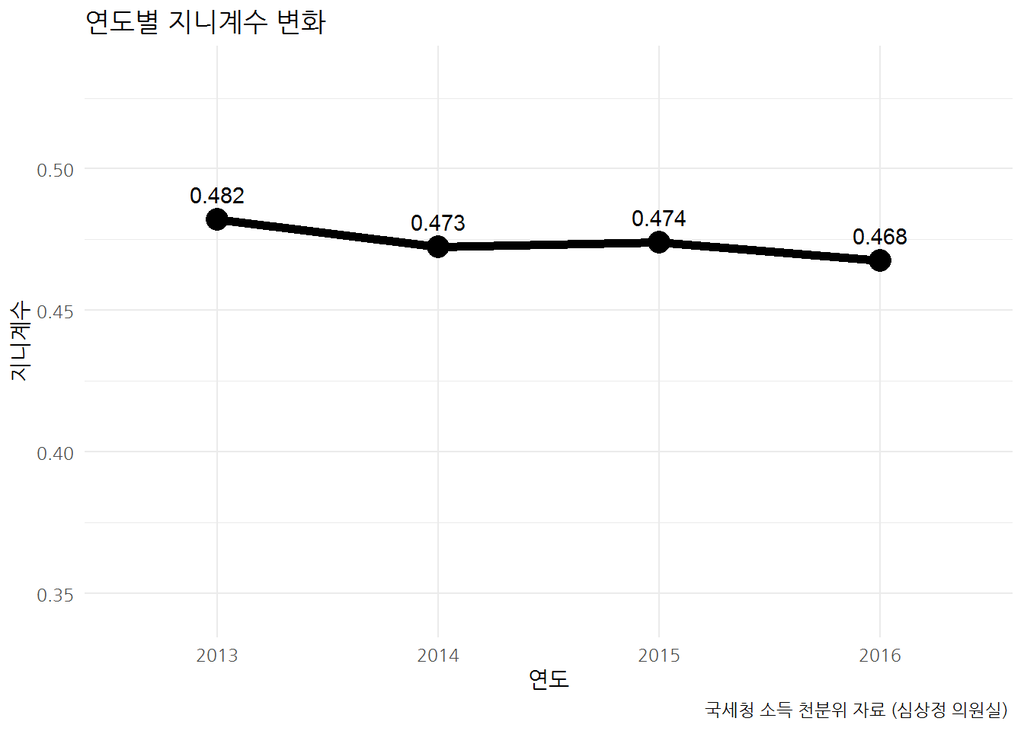

```r
inc_lc %>%
  mutate(`지니계수` = map_dbl(data, ~ineq(.x$`인당급여`))) %>%
  ggplot(aes(x=`연도`, y=`지니계수`, group=1)) +
    geom_line(size=2) +
    geom_point(size=5) +
    geom_text(aes(label = round(`지니계수`,3)), position = position_dodge(width = 1), vjust = -1) +
    expand_limits(y=c(0.344, 0.534)) +
    theme_minimal(base_family = "NanumGothic") +
    labs(x="연도", y="지니계수",
         title="연도별 지니계수 변화",
         caption = "국세청 소득 천분위 자료 (심상정 의원실) ")
```

지니계수를 통해 불평도의 심화 혹은 개선을 파악할 수도 있지만, 시각적으로 불평등도 혹은 소득집중을 파악하는데 로렌츠 곡선이 동원된다. [^5]

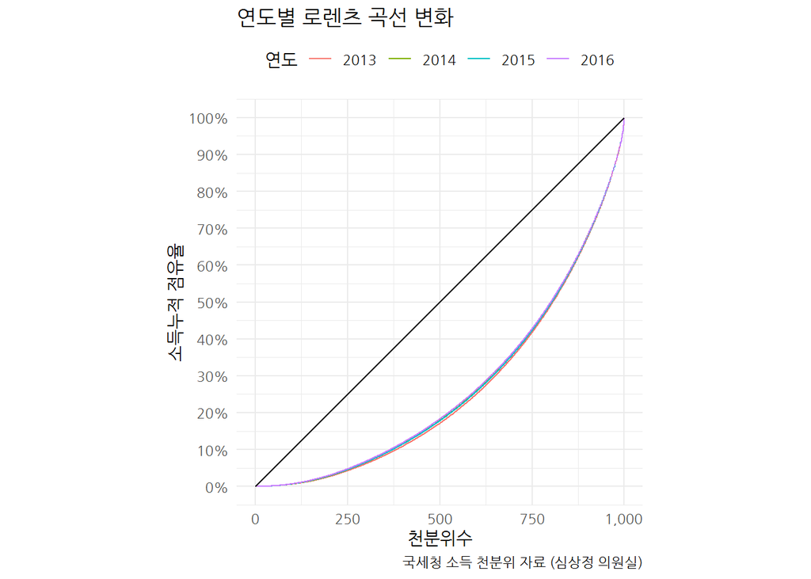

```r
inc_df %>%
  group_by(`연도`) %>%
  arrange(`천분위수`) %>%
  mutate(Lp = cumsum(`인당급여`) / sum(`인당급여`)) %>%
  ggplot(aes(x=`천분위수`, y=Lp, color=`연도`)) +
    # geom_point() +
    geom_line() +
    geom_segment(aes(x = 0, y = 0, xend = 1000, yend = 1), colour = "black") +
    scale_y_continuous(breaks = seq(0,1,0.1), labels = scales::percent) +
    scale_x_continuous(labels = scales::comma) +
    theme_minimal(base_family = "NanumGothic") +
    labs(x="천분위수", y="소득누적 점유율",
         title="연도별 로렌츠 곡선 변화",
         caption = "국세청 소득 천분위 자료 (심상정 의원실)") +
    theme(legend.position = "top") +
    coord_fixed(ratio=1000)
```

# 3 인당 소득 이상점 검출

## 3.1 기술통계량

평균과 표준편차를 계산하여 `Z-점수`를 구하는 공식에 넣어 3을 넘는 것을 이상점으로 판단하여 검출한다.

$$z_i = \frac{x_i - \hat{\mu}}{\hat{\sigma}}$$

정규화를 기준으로 이상점을 추출하면 다음과 같다.

```r
inc_2016_v <- inc_df %>%
  filter(`연도` == 2016) %>%
  pull(`인당급여`)

inc_2016_mean <- mean(inc_2016_v)
inc_2016_sd   <- sd(inc_2016_v)

inc_df %>%
  filter(`연도` == 2016) %>%
  mutate(`점수` = abs((`인당급여` - inc_2016_mean) / inc_2016_sd)) %>%
  mutate(`이상여부` = ifelse(`점수` >3, "이상", "정상") %>% as.factor) %>%
  count(`이상여부`)
```

```
# A tibble: 2 x 2
  이상여부     n
  <fct>    <int>
1 이상        10
2 정상       990
```

```r
inc_df %>%
  filter(`연도` == 2016) %>%
  mutate(`점수` = abs((`인당급여` - inc_2016_mean) / inc_2016_sd)) %>%
  mutate(`이상여부` = ifelse(`점수` >3, "이상", "정상") %>% as.factor) %>%
  filter(`이상여부` %in% "이상") %>%
  DT::datatable() %>%
    DT::formatRound(c("인당급여", "인당근로소득", "인당비근로소득", "점수"), digits=2)
```

|  | 구분 | 인원 | 총급여 | 근로소득금액 | 소득공제액 합계 | 과세표준 | 결정세액 | 연도 | 천분위수 | 인당급여 | 인당근로소득 | 인당비근로소득 | 점수 | 이상여부 |
| --- | --- | --- | --- | --- | --- | --- | --- | --- | --- | --- | --- | --- | --- | --- |
| 1 | 상위 0.1% 내 | 17740 | 121433 | 117093 | 9027 | 112405 | 37036 | 2016 | 999 | 6.84515219842165 | 6.60050732807215 | 0.244644870349493 | 17.5726132728051 | 이상 |
| 2 | 상위 0.2% 내 | 17740 | 54892 | 51782 | 6373 | 48519 | 13904 | 2016 | 998 | 3.09425028184893 | 2.91894024802706 | 0.175310033821871 | 7.44645372099458 | 이상 |
| 3 | 상위 0.3% 내 | 17740 | 43424 | 40486 | 5960 | 37464 | 9984 | 2016 | 997 | 2.447801578354 | 2.28218714768884 | 0.165614430665163 | 5.70126206862742 | 이상 |
| 4 | 상위 0.4% 내 | 17740 | 37408 | 34543 | 5825 | 31583 | 7922 | 2016 | 996 | 2.1086809470124 | 1.94718151071026 | 0.161499436302142 | 4.78575169361514 | 이상 |
| 5 | 상위 0.5% 내 | 17740 | 33716 | 30878 | 5811 | 27905 | 6629 | 2016 | 995 | 1.90056369785795 | 1.74058624577227 | 0.159977452085682 | 4.22390589831172 | 이상 |
| 6 | 상위 0.6% 내 | 17740 | 31266 | 28451 | 5782 | 25483 | 5797 | 2016 | 994 | 1.76245772266065 | 1.60377677564825 | 0.158680947012401 | 3.85106673295599 | 이상 |
| 7 | 상위 0.7% 내 | 17740 | 29435 | 26646 | 5754 | 23682 | 5189 | 2016 | 993 | 1.65924464487035 | 1.50202931228861 | 0.157215332581736 | 3.57242652407176 | 이상 |
| 8 | 상위 0.8% 내 | 17740 | 28023 | 25245 | 5786 | 22238 | 4705 | 2016 | 992 | 1.57965050732807 | 1.42305524239008 | 0.156595264937993 | 3.35754942142593 | 이상 |
| 9 | 상위 0.9% 내 | 17740 | 26899 | 24137 | 5753 | 21146 | 4335 | 2016 | 991 | 1.5162908680947 | 1.36059751972943 | 0.155693348365276 | 3.18649994311579 | 이상 |
| 10 | 상위 1.0% 내 | 17740 | 25992 | 23244 | 5755 | 20237 | 4019 | 2016 | 990 | 1.4651634723788 | 1.31025930101466 | 0.154904171364149 | 3.04847336230858 | 이상 |

이상점 검출을 위해서 강건한 통계량을 바탕으로 이상점을 검출한다. 이를 위해서 평균을 중위수로 치환하고 표준편차를 `MAD(Median absolute deviation)`로 넣어 동일한 방식으로 `Z-점수`를 구하는 공식에 넣어 3을 넘는 것을 이상점으로 판단하여 검출한다.

$$z_i = \frac{x_i - \hat{\text{중위수}}} {\hat{\text{MAD}}}$$

```r
inc_2016_median <- median(inc_2016_v)
inc_2016_mad    <- mad(inc_2016_v)

inc_df %>%
  filter(`연도` == 2016) %>%
  mutate(`강건_점수` = abs((`인당급여` - inc_2016_median) / inc_2016_mad)) %>%
  mutate(`이상여부` = ifelse(`강건_점수` >3, "이상", "정상") %>% as.factor) %>%
  count(`이상여부`)
```

```
# A tibble: 2 x 2
  이상여부     n
  <fct>    <int>
1 이상        57
2 정상       943
```

```r
inc_df %>%
  filter(`연도` == 2016) %>%
  mutate(`강건_점수` = abs((`인당급여` - inc_2016_median) / inc_2016_mad)) %>%
  mutate(`이상여부` = ifelse(`강건_점수` >3, "이상", "정상") %>% as.factor) %>%
  filter(`이상여부` %in% "이상") %>%
  DT::datatable() %>%
    DT::formatRound(c("인당급여", "인당근로소득", "인당비근로소득", "강건_점수"), digits=2)
```

|  | 구분 | 인원 | 총급여 | 근로소득금액 | 소득공제액 합계 | 과세표준 | 결정세액 | 연도 | 천분위수 | 인당급여 | 인당근로소득 | 인당비근로소득 | 강건_점수 | 이상여부 |
| --- | --- | --- | --- | --- | --- | --- | --- | --- | --- | --- | --- | --- | --- | --- |
| 1 | 상위 0.1% 내 | 17740 | 121433 | 117093 | 9027 | 112405 | 37036 | 2016 | 999 | 6.84515219842165 | 6.60050732807215 | 0.244644870349493 | 31.8490649775015 | 이상 |
| 2 | 상위 0.2% 내 | 17740 | 54892 | 51782 | 6373 | 48519 | 13904 | 2016 | 998 | 3.09425028184893 | 2.91894024802706 | 0.175310033821871 | 13.7627101008817 | 이상 |
| 3 | 상위 0.3% 내 | 17740 | 43424 | 40486 | 5960 | 37464 | 9984 | 2016 | 997 | 2.447801578354 | 2.28218714768884 | 0.165614430665163 | 10.645619619448 | 이상 |
| 4 | 상위 0.4% 내 | 17740 | 37408 | 34543 | 5825 | 31583 | 7922 | 2016 | 996 | 2.1086809470124 | 1.94718151071026 | 0.161499436302142 | 9.01042461279433 | 이상 |
| 5 | 상위 0.5% 내 | 17740 | 33716 | 30878 | 5811 | 27905 | 6629 | 2016 | 995 | 1.90056369785795 | 1.74058624577227 | 0.159977452085682 | 8.00691065591841 | 이상 |
| 6 | 상위 0.6% 내 | 17740 | 31266 | 28451 | 5782 | 25483 | 5797 | 2016 | 994 | 1.76245772266065 | 1.60377677564825 | 0.158680947012401 | 7.34098183838158 | 이상 |
| 7 | 상위 0.7% 내 | 17740 | 29435 | 26646 | 5754 | 23682 | 5189 | 2016 | 993 | 1.65924464487035 | 1.50202931228861 | 0.157215332581736 | 6.84330197515303 | 이상 |
| 8 | 상위 0.8% 내 | 17740 | 28023 | 25245 | 5786 | 22238 | 4705 | 2016 | 992 | 1.57965050732807 | 1.42305524239008 | 0.156595264937993 | 6.45950953010731 | 이상 |
| 9 | 상위 0.9% 내 | 17740 | 26899 | 24137 | 5753 | 21146 | 4335 | 2016 | 991 | 1.5162908680947 | 1.36059751972943 | 0.155693348365276 | 6.15399769708224 | 이상 |
| 10 | 상위 1.0% 내 | 17740 | 25992 | 23244 | 5755 | 20237 | 4019 | 2016 | 990 | 1.4651634723788 | 1.31025930101466 | 0.154904171364149 | 5.9074681307533 | 이상 |

[output cut: 47 more lines]

# 4 상자그림(boxplot) 이상점 검출

## 4.1 단변량 이상점 검출 [^6]

[상자그림(boxplot)](https://ko.wikipedia.org/wiki/상자_수염_그림)을 통해 분포를 시각화하거나 서로 다른 집단간 분포를 쉽게 시각화하여 비교가 가능하다. 특히, 이상점을 한눈에 볼 수 있게 `ggplot`을 활용하여 시각화하는 방법은 다음과 같다.

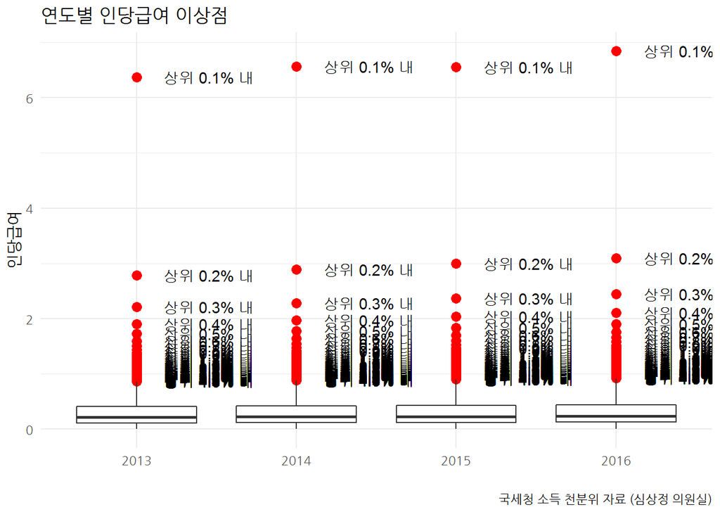

```r
is_outlier <- function(x) {
  return(x < quantile(x, 0.25) - 1.5 * IQR(x) | x > quantile(x, 0.75) + 1.5 * IQR(x))
}

inc_df %>%
  group_by(`연도`) %>%
  mutate(inc_outlier = is_outlier(`인당급여`)) %>%
  ungroup() %>%
  ggplot(aes(y=`인당급여`, x=`연도`)) +
    geom_boxplot(outlier.colour = "red", outlier.size = 3) +
    geom_text(aes(label=ifelse(inc_outlier, `구분`, "")), na.rm=TRUE, hjust=-0.3) +
    theme_minimal(base_family = "NanumGothic") +
    labs(x="", y="인당급여",
         title="연도별 인당급여 이상점",
         caption = "국세청 소득 천분위 자료 (심상정 의원실)")
```

## 4.2 강건한 상자그림(boxplot) [^7]

> “It is perfect to use both classical and robust methods routinely, and only worry when they differ enough to matter… But when they differ, you should think hard.” **J.W. Tukey (1979)**

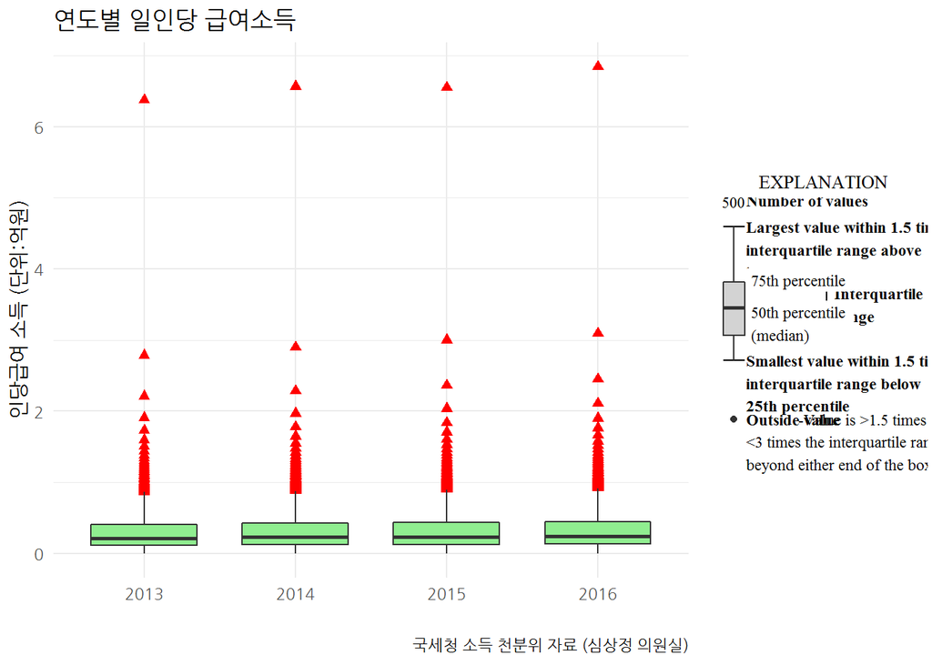

```r
ggplot_box_legend <- function(family = "serif"){

  # Create data to use in the boxplot legend:
  set.seed(100)

  sample_df <- data.frame(parameter = "test",
                        values = sample(500))

  # Extend the top whisker a bit:
  sample_df$values[1:100] <- 701:800
  # Make sure there's only 1 lower outlier:
  sample_df$values[1] <- -350

  # Function to calculate important values:
  ggplot2_boxplot <- function(x){

    quartiles <- as.numeric(quantile(x,
                                     probs = c(0.25, 0.5, 0.75)))

    names(quartiles) <- c("25th percentile",
                          "50th percentile\n(median)",
                          "75th percentile")

    IQR <- diff(quartiles[c(1,3)])

    upper_whisker <- max(x[x < (quartiles[3] + 1.5 * IQR)])
    lower_whisker <- min(x[x > (quartiles[1] - 1.5 * IQR)])

    upper_dots <- x[x > (quartiles[3] + 1.5*IQR)]
    lower_dots <- x[x < (quartiles[1] - 1.5*IQR)]

    return(list("quartiles" = quartiles,
                "25th percentile" = as.numeric(quartiles[1]),
                "50th percentile\n(median)" = as.numeric(quartiles[2]),
                "75th percentile" = as.numeric(quartiles[3]),
                "IQR" = IQR,
                "upper_whisker" = upper_whisker,
                "lower_whisker" = lower_whisker,
                "upper_dots" = upper_dots,
                "lower_dots" = lower_dots))
  }

  # Get those values:
  ggplot_output <- ggplot2_boxplot(sample_df$values)

  # Lots of text in the legend, make it smaller and consistent font:
  update_geom_defaults("text",
                     list(size = 3,
                          hjust = 0,
                          family = family))
  # Labels don't inherit text:
  update_geom_defaults("label",
                     list(size = 3,
                          hjust = 0,
                          family = family))

  # Create the legend:
  # The main elements of the plot (the boxplot, error bars, and count)
  # are the easy part.
  # The text describing each of those takes a lot of fiddling to
  # get the location and style just right:
  explain_plot <- ggplot() +
    stat_boxplot(data = sample_df,
                 aes(x = parameter, y=values),
                 geom ='errorbar', width = 0.3) +
    geom_boxplot(data = sample_df,
                 aes(x = parameter, y=values),
                 width = 0.3, fill = "lightgrey") +
    geom_text(aes(x = 1, y = 950, label = "500"), hjust = 0.5) +
    geom_text(aes(x = 1.17, y = 950,
                  label = "Number of values"),
              fontface = "bold", vjust = 0.4) +
    theme_minimal(base_size = 5, base_family = family) +
    geom_segment(aes(x = 2.3, xend = 2.3,
                     y = ggplot_output[["25th percentile"]],
                     yend = ggplot_output[["75th percentile"]])) +
    geom_segment(aes(x = 1.2, xend = 2.3,
                     y = ggplot_output[["25th percentile"]],
                     yend = ggplot_output[["25th percentile"]])) +
    geom_segment(aes(x = 1.2, xend = 2.3,
                     y = ggplot_output[["75th percentile"]],
                     yend = ggplot_output[["75th percentile"]])) +
    geom_text(aes(x = 2.4, y = ggplot_output[["50th percentile\n(median)"]]),
              label = "Interquartile\nrange", fontface = "bold",
              vjust = 0.4) +
    geom_text(aes(x = c(1.17,1.17),
                  y = c(ggplot_output[["upper_whisker"]],
                        ggplot_output[["lower_whisker"]]),
                  label = c("Largest value within 1.5 times\ninterquartile range above\n75th percentile",
                            "Smallest value within 1.5 times\ninterquartile range below\n25th percentile")),
                  fontface = "bold", vjust = 0.9) +
    geom_text(aes(x = c(1.17),
                  y =  ggplot_output[["lower_dots"]],
                  label = "Outside value"),
              vjust = 0.5, fontface = "bold") +
    geom_text(aes(x = c(1.9),
                  y =  ggplot_output[["lower_dots"]],
                  label = "-Value is >1.5 times and"),
              vjust = 0.5) +
    geom_text(aes(x = 1.17,
                  y = ggplot_output[["lower_dots"]],
                  label = "<3 times the interquartile range\nbeyond either end of the box"),
              vjust = 1.5) +
    geom_label(aes(x = 1.17, y = ggplot_output[["quartiles"]],
                  label = names(ggplot_output[["quartiles"]])),
              vjust = c(0.4,0.85,0.4),
              fill = "white", label.size = 0) +
    ylab("") + xlab("") +
    theme(axis.text = element_blank(),
          axis.ticks = element_blank(),
          panel.grid = element_blank(),
          aspect.ratio = 4/3,
          plot.title = element_text(hjust = 0.5, size = 10)) +
    coord_cartesian(xlim = c(1.4,3.1), ylim = c(-600, 900)) +
    labs(title = "EXPLANATION")

  return(explain_plot)

}


inc_boxplot_g <- inc_df %>%
  ggplot(aes(x=`연도`, y= `인당급여`)) +
    geom_boxplot(outlier.colour = "red", outlier.shape = 17, outlier.size = 2,
                 fill = "lightgreen", width = 0.7) +
    labs(x="", y="인당급여 소득 (단위:억원)",
         title = "연도별 일인당 급여소득",
         caption = "국세청 소득 천분위 자료 (심상정 의원실)") +
    theme_minimal(base_family = "NanumGothic")

cowplot::plot_grid(inc_boxplot_g, ggplot_box_legend(), rel_widths=c(3,1))
```

[Box Plot Diagram to Identify Outliers](https://www.whatissixsigma.net/box-plot-diagram-to-identify-outliers/)의 공식을 참조하여 상위 25% 분위수값에 $1.5 IQR $을 통해서 이상점을 발라낸다.

```r
inc_boxplot_outlier_g <- inc_df %>%
  filter(`연도` == 2016) %>%
  ggplot(aes(y=`인당급여`)) +
    geom_boxplot()

inc_IQR <- inc_df %>%
  filter(`연도` == 2016) %>%
  summarise(IQR = IQR(`인당급여`)) %>%
  pull()

inc_df %>%
  filter(`연도` == 2016) %>%
  mutate(outlier = ifelse(`인당급여` > (quantile(inc_2016_v, 0.75) + 1.5 * inc_IQR), "이상점", "정상")) %>%
  filter(outlier == "이상점") %>%
  DT::datatable()
```

|  | 구분 | 인원 | 총급여 | 근로소득금액 | 소득공제액 합계 | 과세표준 | 결정세액 | 연도 | 천분위수 | 인당급여 | 인당근로소득 | 인당비근로소득 | outlier |
| --- | --- | --- | --- | --- | --- | --- | --- | --- | --- | --- | --- | --- | --- |
| 1 | 상위 0.1% 내 | 17740 | 121433 | 117093 | 9027 | 112405 | 37036 | 2016 | 999 | 6.84515219842165 | 6.60050732807215 | 0.244644870349493 | 이상점 |
| 2 | 상위 0.2% 내 | 17740 | 54892 | 51782 | 6373 | 48519 | 13904 | 2016 | 998 | 3.09425028184893 | 2.91894024802706 | 0.175310033821871 | 이상점 |
| 3 | 상위 0.3% 내 | 17740 | 43424 | 40486 | 5960 | 37464 | 9984 | 2016 | 997 | 2.447801578354 | 2.28218714768884 | 0.165614430665163 | 이상점 |
| 4 | 상위 0.4% 내 | 17740 | 37408 | 34543 | 5825 | 31583 | 7922 | 2016 | 996 | 2.1086809470124 | 1.94718151071026 | 0.161499436302142 | 이상점 |
| 5 | 상위 0.5% 내 | 17740 | 33716 | 30878 | 5811 | 27905 | 6629 | 2016 | 995 | 1.90056369785795 | 1.74058624577227 | 0.159977452085682 | 이상점 |
| 6 | 상위 0.6% 내 | 17740 | 31266 | 28451 | 5782 | 25483 | 5797 | 2016 | 994 | 1.76245772266065 | 1.60377677564825 | 0.158680947012401 | 이상점 |
| 7 | 상위 0.7% 내 | 17740 | 29435 | 26646 | 5754 | 23682 | 5189 | 2016 | 993 | 1.65924464487035 | 1.50202931228861 | 0.157215332581736 | 이상점 |
| 8 | 상위 0.8% 내 | 17740 | 28023 | 25245 | 5786 | 22238 | 4705 | 2016 | 992 | 1.57965050732807 | 1.42305524239008 | 0.156595264937993 | 이상점 |
| 9 | 상위 0.9% 내 | 17740 | 26899 | 24137 | 5753 | 21146 | 4335 | 2016 | 991 | 1.5162908680947 | 1.36059751972943 | 0.155693348365276 | 이상점 |
| 10 | 상위 1.0% 내 | 17740 | 25992 | 23244 | 5755 | 20237 | 4019 | 2016 | 990 | 1.4651634723788 | 1.31025930101466 | 0.154904171364149 | 이상점 |

[output cut: 38 more lines]

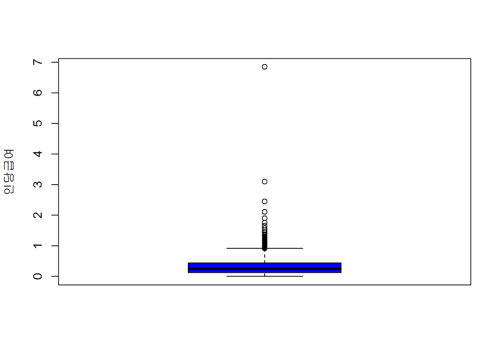

```
 [1] 6.8451522 3.0942503 2.4478016 2.1086809 1.9005637 1.7624577 1.6592446
 [8] 1.5796505 1.5162909 1.4651635 1.4220168 1.3841037 1.3506201 1.3216460
[15] 1.2956595 1.2716460 1.2493799 1.2289741 1.2101466 1.1949831 1.1798095
[22] 1.1649380 1.1507892 1.1370913 1.1242390 1.1120631 1.1005637 1.0894025
[29] 1.0788050 1.0685457 1.0583958 1.0485344 1.0389515 1.0295378 1.0204622
[36] 1.0116122 1.0028749 0.9943630 0.9860767 0.9779030 0.9700130 0.9625141
[43] 0.9555806 0.9483089 0.9411499 0.9341037 0.9272266 0.9205750
```

```r
## 교차검증
boxplot(inc_2016_v, col="blue", ylab="인당급여")$out
```

수정된 상자그림(Adjusted boxplot)은 [robustbase: Basic Robust Statistics](https://cran.r-project.org/web/packages/robustbase/index.html) 팩키지에 포함되어 있는 `adjboxStats()`함수로 구현이 가능한데 이론적인 배경은 [Hubert and Vandervieren (2008), “An Adjusted Boxplot for Skewed Distributions”, Computational Statistics & Data Analysis 52(12):5186-5201](https://www.researchgate.net/publication/4749681_An_Adjusted_Boxplot_for_Skewed_Distributions) 참조한다.

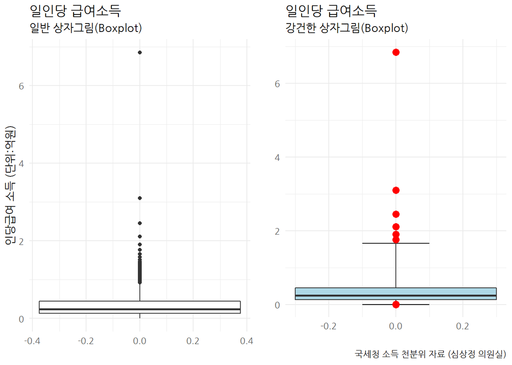

```r
## 상자그림
normal_boxplot_g <- inc_df %>%
  filter(`연도` == 2016) %>%
  ggplot(aes(y=`인당급여`)) +
    geom_boxplot() +
    labs(x="", y="인당급여 소득 (단위:억원)",
         title = "일인당 급여소득",
         subtitle = "일반 상자그림(Boxplot)") +
    theme_minimal(base_family = "NanumGothic")

## 강건 상자그림
library(robustbase)
inc_adjbox_stats <- adjboxStats(inc_2016_v)$stats

robust_boxplot_g <- inc_df %>%
  filter(`연도` == 2016) %>%
  ggplot(aes(y = `인당급여`)) +
    stat_boxplot(geom = "errorbar", width = 0.2, coef = 1.5*exp(3*mc(inc_2016_v))) +
    geom_boxplot(ymin = inc_adjbox_stats[1],
                 ymax = inc_adjbox_stats[5],
                 middle = inc_adjbox_stats[3],
                 upper = inc_adjbox_stats[4],
                 lower = inc_adjbox_stats[2],
                 outlier.shape = NA,
                 fill = "lightblue",
                 width = 0.6) +
     geom_point(data= inc_df %>% filter(`연도` == 2016) %>%
                  filter(`인당급여` < inc_adjbox_stats[1] | `인당급여` > inc_adjbox_stats[5]),
              aes(x=0, y=`인당급여`), col = "red", size = 3, shape = 16) +
    labs(x="", y="",
         title = "일인당 급여소득",
         subtitle = "강건한 상자그림(Boxplot)",
         caption = "국세청 소득 천분위 자료 (심상정 의원실)") +
    theme_minimal(base_family = "NanumGothic")

cowplot::plot_grid(normal_boxplot_g, robust_boxplot_g)
```

```r
## 대칭, 비대칭 상자그림
par(mfrow=c(1,2))
boxplot(inc_2016_v, col="lightblue", ylab="인당급여")$out
```

```
 [1] 6.8451522 3.0942503 2.4478016 2.1086809 1.9005637 1.7624577 1.6592446
 [8] 1.5796505 1.5162909 1.4651635 1.4220168 1.3841037 1.3506201 1.3216460
[15] 1.2956595 1.2716460 1.2493799 1.2289741 1.2101466 1.1949831 1.1798095
[22] 1.1649380 1.1507892 1.1370913 1.1242390 1.1120631 1.1005637 1.0894025
[29] 1.0788050 1.0685457 1.0583958 1.0485344 1.0389515 1.0295378 1.0204622
[36] 1.0116122 1.0028749 0.9943630 0.9860767 0.9779030 0.9700130 0.9625141
[43] 0.9555806 0.9483089 0.9411499 0.9341037 0.9272266 0.9205750
```

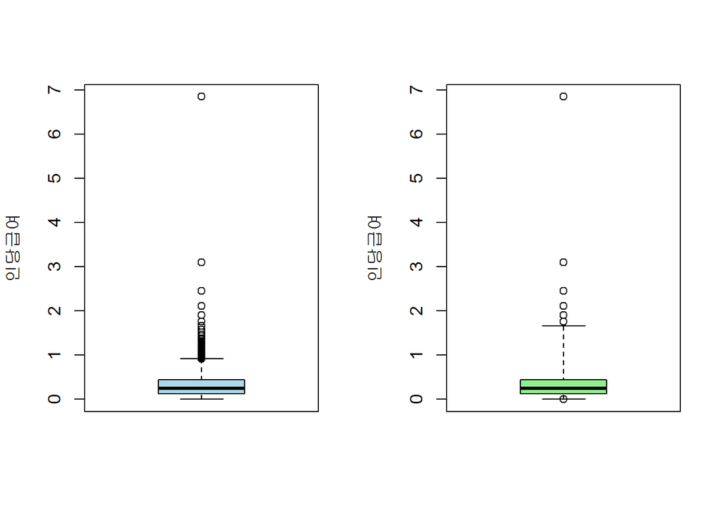

```
 [1] 6.8451521984 3.0942502818 2.4478015784 2.1086809470 1.9005636979
 [6] 1.7624577227 0.0052423901 0.0047350620 0.0042277339 0.0037201962
[11] 0.0031567080 0.0026493799 0.0020856821 0.0015219842 0.0009582864
[16] 0.0003945885 0.0000000000 0.0000000000 0.0000000000 0.0000000000
```

```r
adjbox(inc_2016_v,  col="lightgreen", ylab="인당급여")$out
```

## 4.3 이변량 이상점 검출 [^8] [^9]

상자그림은 단변량 분포를 시각화하고 이상점을 추출할 때 적합하지만, 이변량인 경우 `bagplot()`을 통해 분포를 시각화하고 이상점을 추출하는 것이 가능해졌다.

깊이 중위수(depth median)이 중심이 되며, $\frac{n}{2}$의 데이터가 가운데 “가방(bag)”에 몰려있고, 가방을 3배 확장하여 펜스(fence)를 두르고 그 밖에 위치한 점은 이상점으로 별도로 표시한다.

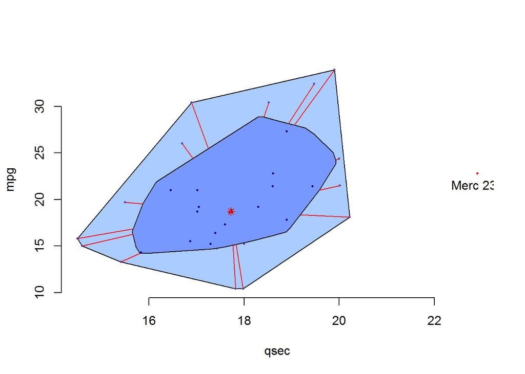

```r
library(aplpack)

data(mtcars)
mtcars$model_name <- rownames(mtcars)

# with(mtcars,
#      bagplot(qsec, mpg, xlab="qsec", ylab="mpg", show.outlier= TRUE,
#              show.looppoints=TRUE,
#              show.bagpoints=TRUE,dkmethod=2,
#              show.whiskers=TRUE,show.loophull=TRUE,
#              show.baghull=TRUE,verbose=FALSE))

# 이상점 표기
mtcars_bagplot <- with(mtcars, bagplot(qsec, mpg, xlab="qsec", ylab="mpg"))
mtcars_outlier <- as.data.frame(mtcars_bagplot$pxy.outlier)
names(mtcars_outlier) <- c("qsec", "mpg")
mtcars_outliers <- left_join(mtcars_outlier, mtcars)

text(mtcars_outliers$qsec, mtcars_outliers$mpg, labels=mtcars_outliers$model_name, pos=1)
```

# 5 다변량 이상점 검출 -마할라노비스

## 5.1 마할라노비스 거리 맛보기 [^10] [^11]

다차원 공간에서 이상점을 찾아내는 간단한 방법이 [마할라노비스 거리](https://en.wikipedia.org/wiki/Mahalanobis_distance)를 활용하는 것이다. 유클리디안 거리를 다차원 공간으로 확장한 것으로 생각하면 쉽게 이해할 수 있다.

평균 $\vec{\mu} = ( \mu_1, \mu_2, \mu_3, \dots , \mu_N )^T$와 공분산 $S$를 갖는 벡터 $\vec{x} = ( x_1, x_2, x_3, \dots, x_N )^T$에 대한  
마할라노비스 거리에 대한 수학적 정의는 다음과 같다.

$D_M(\vec{x}) = \sqrt{(\vec{x} - \vec{\mu})^T S^{-1} (\vec{x}-\vec{\mu})}$

신장과 체중데이터를 바탕으로 마할라노비스 이상점을 검출해보자.

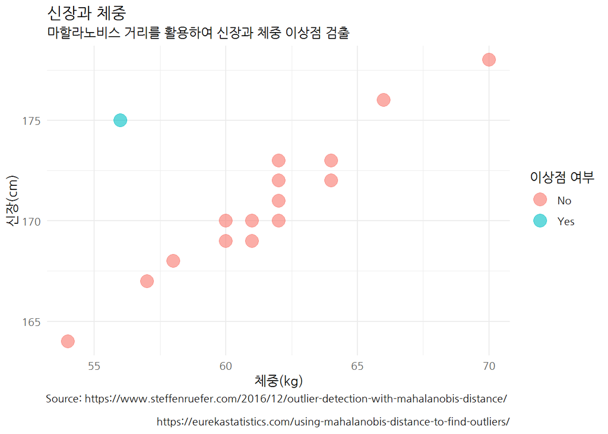

```r
# 신장과 체중 데이터
df <- tibble(height_cm =
               c(164, 167, 168, 169, 169, 170, 170, 170, 171, 172, 172, 173, 173, 175, 176, 178),
              weight_kg =
               c( 54,  57,  58,  60,  61,  60,  61,  62,  62,  64,  62,  62,  64,  56,  66,  70))


# 신장과 체중 분포에 대한 마할라노비스 거리 계산
m_dist <- mahalanobis(df[, 1:2], colMeans(df[, 1:2]), cov(df[, 1:2]))
df$m_dist <- round(m_dist, 2)

# 마할라노비스 이상점 - 임계점을 12로 설정
df$outlier_maha <- "No"
df$outlier_maha[df$m_dist > 12] <- "Yes"

# 시각화
ggplot(df, aes(x = weight_kg, y = height_cm, color = outlier_maha)) +
    geom_point(size = 5, alpha = 0.6) +
    theme_minimal(base_family = "NanumGothic") +
    labs(x="체중(kg)", y="신장(cm)",
         color = "이상점 여부",
         title = "신장과 체중",
         subtitle = "마할라노비스 거리를 활용하여 신장과 체중 이상점 검출",
         caption = "Source: https://www.steffenruefer.com/2016/12/outlier-detection-with-mahalanobis-distance/ \n
                            https://eurekastatistics.com/using-mahalanobis-distance-to-find-outliers/") +
    scale_y_continuous(breaks = seq(160, 200, 5)) +
    scale_x_continuous(breaks = seq(35, 80, 5))
```

## 5.2 마할라노비스 거리 적용시 주의점 {#mahalanobis-distance-caveat}

마할라노비스 거리를 활용하여 이상점을 추출할 수 있으나 선형적인 관계가 존재할 때 유용하고 비선형인 경우 이상점을 잘못 검출할 수 있다.

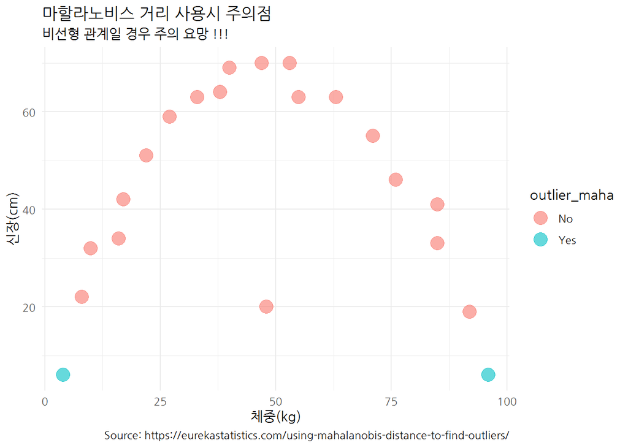

```r
# 주의점 ------------------------------------------------------------------

caveats_df <- data.frame(x=c(4,  8, 10, 16, 17, 22, 27, 33, 38, 40, 47, 48, 53, 55, 63, 71, 76, 85, 85, 92, 96),
                         y=c(6, 22, 32, 34, 42, 51, 59, 63, 64, 69, 70, 20, 70, 63, 63, 55, 46, 41, 33, 19,  6))

caveats_dist <- mahalanobis(caveats_df[, 1:2], colMeans(caveats_df[, 1:2]), cov(caveats_df[, 1:2]))
caveats_df$m_dist <- round(caveats_dist, 2)

# Mahalanobis Outliers - Threshold set to 12
caveats_df$outlier_maha <- "No"
caveats_df$outlier_maha[caveats_df$m_dist > 5] <- "Yes"

ggplot(caveats_df, aes(x = x, y = y, color = outlier_maha)) +
    geom_point(size = 5, alpha = 0.6) +
    labs(title = "마할라노비스 거리 사용시 주의점",
         subtitle = "비선형 관계일 경우 주의 요망 !!!",
         caption = "Source: https://eurekastatistics.com/using-mahalanobis-distance-to-find-outliers/") +
    ylab("신장(cm)") + xlab("체중(kg)") +
    theme_minimal(base_family = "NanumGothic")
```

## 5.3 마할라노비스 이상점 탐지

다변량 이상점 검출을 위해서 **마할라노비스 거리**를 활용하는데 유클리디언 거리와 비교하여 변수간의 공분산관계를 반영할 수 있다는 점에서 큰 장점이 있다. 데이터로 `MASS` 팩키지 `Animals` 데이터셋을 사용하자. `Animals` 데이터셋은 날짐승이 아닌 인간포함 육상 동물 28종에 대한 평균 체중과 평균 뇌무게를 포함하고 있다.

```r
library(MASS)
data("Animals")

animals_df <- Animals %>%
  rownames_to_column(var="animal") %>%
  tbl_df() %>%
  mutate(log_body = round(log(body), 3),
         log_brain = round(log(brain),3))

animals_df %>%
  DT::datatable()
```

|  | animal | body | brain | log_body | log_brain |
| --- | --- | --- | --- | --- | --- |
| 1 | Mountain beaver | 1.35 | 8.1 | 0.3 | 2.092 |
| 2 | Cow | 465 | 423 | 6.142 | 6.047 |
| 3 | Grey wolf | 36.33 | 119.5 | 3.593 | 4.783 |
| 4 | Goat | 27.66 | 115 | 3.32 | 4.745 |
| 5 | Guinea pig | 1.04 | 5.5 | 0.039 | 1.705 |
| 6 | Dipliodocus | 11700 | 50 | 9.367 | 3.912 |
| 7 | Asian elephant | 2547 | 4603 | 7.843 | 8.434 |
| 8 | Donkey | 187.1 | 419 | 5.232 | 6.038 |
| 9 | Horse | 521 | 655 | 6.256 | 6.485 |
| 10 | Potar monkey | 10 | 115 | 2.303 | 4.745 |

[output cut: 18 more lines]

### 5.3.1 동물 뇌/체중 데이터 시각화

`Brachiosaurus`, `Dipliodocus`, `Triceratops` 동물 3종을 이상점으로 검출하는 방법이 필요함이 파악된다.

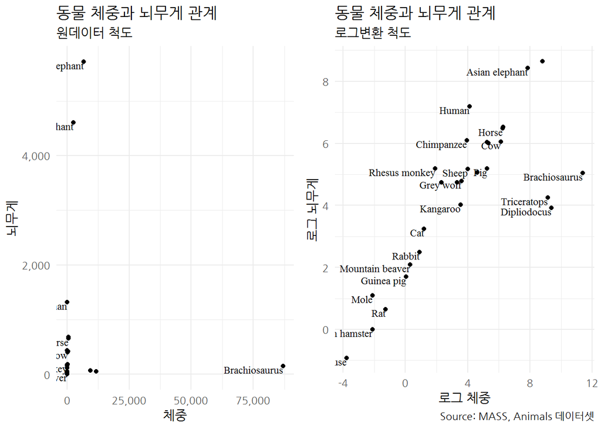

```r
orig_g <- animals_df %>%
  ggplot(aes(x=body, y=brain)) +
    geom_point() +
    labs(x = "체중",
         y = "뇌무게",
         title = "동물 체중과 뇌무게 관계",
         subtitle = "원데이터 척도")+
    theme_minimal(base_family = "NanumGothic") +
    scale_x_continuous(labels = scales::comma) +
    scale_y_continuous(labels = scales::comma) +
    geom_text(aes(label=animal), check_overlap = TRUE, vjust=1, hjust=1)

log_g <- animals_df %>%
  ggplot(aes(x=log_body, y=log_brain)) +
    geom_point() +
    labs(x = "로그 체중",
       y = "로그 뇌무게",
       title = "동물 체중과 뇌무게 관계",
       subtitle = "로그변환 척도",
       caption = "Source: MASS, Animals 데이터셋") +
    theme_minimal(base_family = "NanumGothic") +
    scale_x_continuous(labels = scales::comma) +
    scale_y_continuous(labels = scales::comma) +
    geom_text(aes(label=animal), check_overlap = TRUE, vjust=1, hjust=1)

cowplot::plot_grid(orig_g, log_g)
```

### 5.3.2 이변량 상자그림 이상점 검출

`aplpack` 팩키지 `bagplot()` 함수를 통해서 이변량 상자그림을 도식화하고 이상점을 추출해 내는 것도 가능하다.

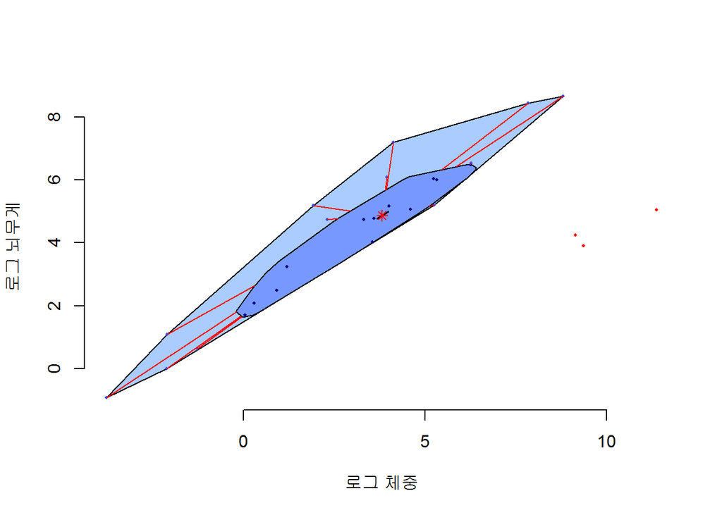

```r
# 이상점 표기
animals_bagplot <- with(animals_df, bagplot(log_body, log_brain, xlab="로그 체중", ylab="로그 뇌무게"))

animals_outlier <- as.data.frame(animals_bagplot$pxy.outlier) %>%
  `colnames<-`(c("log_body", "log_brain"))

animals_outliers <- left_join(animals_outlier, animals_df)

text(animals_outliers$log_body, animals_outliers$log_brain, labels=animals_outliers$name, pos=1)
```

```r
animals_outliers %>%
  dplyr::select(animal, everything()) %>%
  DT::datatable()
```

|  | animal | log_body | log_brain | body | brain |
| --- | --- | --- | --- | --- | --- |
| 1 | Dipliodocus | 9.367 | 3.912 | 11700 | 50 |
| 2 | Triceratops | 9.148 | 4.248 | 9400 | 70 |
| 3 | Brachiosaurus | 11.374 | 5.04 | 87000 | 154.5 |

### 5.3.3 다변량 이상점 탐지

데이터가 $d-$차원 정규분포를 따른다고 가정하면 마할라노비스 거리는 자유도 $d$를 갖는 $\chi^2$ 분포를 다른다. 마할라노비스 거리를 바탕으로 변수 다수를 사용해서 이상점을 추출할 경우 $\chi^2$ 분포와 비교하여 $\alpha = 0.001$을 기준으로 임계값은 다음과 같다. 즉, 아래 임계값을 넘는 것은 이상점으로 간주한다.

| 자유도 | 임계값 |
| --- | --- |
| 2 | 13.82 |
| 3 | 16.27 |
| 4 | 18.47 |
| 5 | 20.52 |
| 6 | 22.46 |
| 7 | 24.32 |
| 8 | 26.13 |
| 9 | 27.88 |
| 10 | 29.59 |

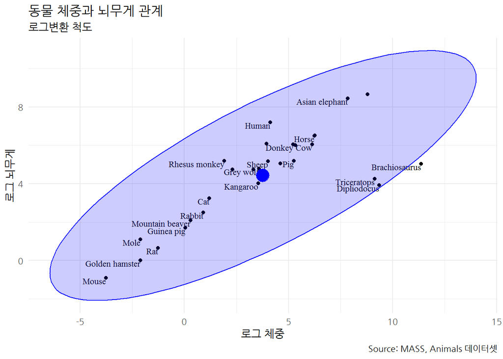

```r
## 이상점 임계값 도출
animals_md_df <- animals_df %>%
  dplyr::select(log_body, log_brain)

animal_mean <- colMeans(animals_md_df)
animal_cov <- cov(animals_md_df)
animal_rad <- sqrt(qchisq(0.975, df = ncol(animals_md_df)))

m_dist <- mahalanobis(animals_md_df, animal_mean, animal_cov)

## 이상점 임계값 시각화
library(car)
animal_ellipse_df <- data.frame(ellipse(center = animal_mean,
        shape = animal_cov,
        radius = animal_rad, segments = 100, draw = FALSE)) %>%
  `colnames<-`(c("log_body", "log_brain"))


animals_df %>%
  ggplot(aes(x=log_body, y=log_brain)) +
    geom_point() +
    labs(x = "로그 체중",
       y = "로그 뇌무게",
       title = "동물 체중과 뇌무게 관계",
       subtitle = "로그변환 척도",
       caption = "Source: MASS, Animals 데이터셋") +
    theme_minimal(base_family = "NanumGothic") +
    scale_x_continuous(labels = scales::comma) +
    scale_y_continuous(labels = scales::comma) +
    geom_text(aes(label=animal), check_overlap = TRUE, vjust=1, hjust=1) +
    geom_polygon(data=animal_ellipse_df, color = "blue", fill = "blue", alpha = 0.2) +
    geom_point(aes(x = animal_mean[1], y = animal_mean[2]), color = "blue", size = 6)
```

### 5.3.4 강건 다변량 이상점 탐지

Rousseeuw가 제안한 “MCD(Minimum Covariance Determinant)”는 가장 일반적인 강건한 다변량 추정량으로 받아들여진다. `animals_mcd$center`, `animals_mcd$cov`을 상기 코드에 꽂아 넣으면 강건한 다변량 이상점 탐지 기법이 완성된다.

```r
# animal_mvoutlier <- mvoutlier::chisq.plot(animals_md_df)
animals_mcd <- robustbase::covMcd(animals_md_df)

animals_mcd$center
```

```
 log_body log_brain
 3.028826  4.275609
```

```r
animals_mcd$cov
```

```
          log_body log_brain
log_body   18.8587  14.15960
log_brain  14.1596  11.03236
```

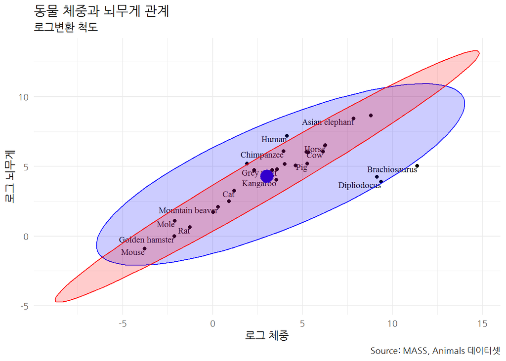

```r
## 이상점 임계값 시각화
library(car)
animal_ellipse_mcd_df <- data.frame(ellipse(center = animals_mcd$center,
        shape = animals_mcd$cov,
        radius = animal_rad, segments = 100, draw = FALSE)) %>%
  `colnames<-`(c("log_body", "log_brain"))

animals_df %>%
  ggplot(aes(x=log_body, y=log_brain)) +
    geom_point() +
    labs(x = "로그 체중",
       y = "로그 뇌무게",
       title = "동물 체중과 뇌무게 관계",
       subtitle = "로그변환 척도",
       caption = "Source: MASS, Animals 데이터셋") +
    theme_minimal(base_family = "NanumGothic") +
    scale_x_continuous(labels = scales::comma) +
    scale_y_continuous(labels = scales::comma) +
    geom_text(aes(label=animal), check_overlap = TRUE, vjust=1, hjust=1) +
    geom_polygon(data=animal_ellipse_df, color = "blue", fill = "blue", alpha = 0.2) +
    geom_point(aes(x = animals_mcd$center[1], y = animals_mcd$center[2]), color = "blue", size = 6) +
    geom_polygon(data=animal_ellipse_mcd_df, color = "red", fill = "red", alpha = 0.2)
```

[^1]: [Outlier Detection Techniques](http://www.dbs.ifi.lmu.de/~zimek/publications/KDD2010/kdd10-outlier-tutorial.pdf)
[^2]: [보도자료 - 심상정, 소득 천분위 자료 공개 (종합, 근로, 배당, 이자 소득)](https://blog.naver.com/713sim/221350785950)
[^3]: [ARTHUR CHARPENTIER(17/01/2015), “MODELING INCOMES AND INEQUALITIES”](https://freakonometrics.hypotheses.org/18859)
[^4]: [Wikipedia, List of countries by income equality](https://en.wikipedia.org/wiki/List_of_countries_by_income_equality)
[^5]: [로렌츠 곡선과 지니계수](http://blog.daum.net/kfs-jjang/15858787)
[^6]: [Labeling Outliers of Boxplots in R](http://stackoverflow.com/questions/33524669/labeling-outliers-of-boxplots-in-r)
[^7]: [Laura DeCicco, “Exploring ggplot2 boxplots - Defining limits and adjusting style”](https://owi.usgs.gov/blog/boxplots/)
[^8]: [aplpack - Another Plot PACKage: stem.leaf, bagplot, faces, spin3R, plotsummary, plothulls, and some slider functions](https://cran.r-project.org/web/packages/aplpack/)
[^9]: [Rousseeuw, Peter J., Ruts I., Tukey J.W. (1999). “The Bagplot: A Bivariate Boxplot”. The American Statistician. 53 (4): 382–387](http://venus.unive.it/romanaz/ada2/bagplot.pdf)
[^10]: [Outlier Detection with Mahalanobis Distance](https://www.steffenruefer.com/2016/12/outlier-detection-with-mahalanobis-distance/)
[^11]: [Using Mahalanobis Distance to Find Outliers](https://eurekastatistics.com/using-mahalanobis-distance-to-find-outliers/)